# Twitter Analysis 2015

## Introduction

In this project, we would like to understand what people’s attitude to libraries and what do they say about libraries in 2015 (from 01-01-2015 to 12-31-2015). We used key twitter search terms “library”, “libraries”, “librarian”, “librarians”, “librarianship”, and scrapped all tweets from twitter. Our tweets dataset contains 97199 observations.

We cleaned the data by 1. changed all text into lower cases 2. removed stopwords suchs as “a”, “the”, etc. We also took “library”, “libraries”, “librarian”, “librarians” out from the text because they are our key searching words 3. removed punctuation 4. remove numbers 5. remove stem words (A **stem** is a part of word, e.g de-, -(e)d, -(e)s.)

We also calculated the sentiment score to each tweets. A positive score means positive sentiment and a negative score means negative sentiment.

## The 20 most common words for all tweets

The most common words in 2015 tweets about libraries are shown below

```
##          word  freq
## book     book 11226
## new       new  6559
## get       get  5321
## public public  4695
## school school  4450
## today   today  4113
## read     read  4044
## like     like  3472
## free     free  3420
## make     make  3281
## day       day  3061
## open     open  2935
## one       one  2890
## love     love  2802
## come     come  2800
## look     look  2783
## see       see  2783
## nan       nan  2751
## via       via  2461
## need     need  2433
```

The WordCloud of the first 150 most common words for all tweets

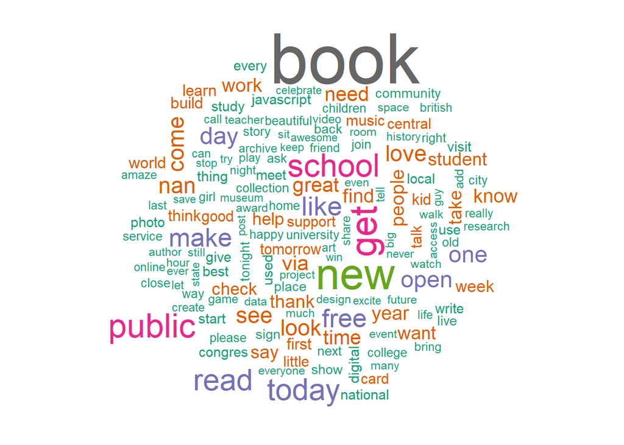

```r
cor.special <- brewer.pal(8,"Dark2")
d.1 <- d[1:150,]
wordcloud(d.1$word, d.1$freq, scale=c(4.7,.47),  # make a word cloud
          colors=cor.special, ordered.colors=F)
```

## Most common adjective words

We also would like to analyze the most common adjectives in the tweets to see if we can have a better understanding of people’s attitudes to libraries.

The 20 most common adjective words

```
##           word freq
## 110        new 6559
## 135     public 4695
## 117       open 2935
## 67       great 2413
## 64        good 1496
## 91      little 1428
## 22     central 1407
## 84  javascript 1353
## 109   national 1294
## 40     digital 1291
## 93       local 1246
## 92        live 1135
## 116        old 1111
## 14   beautiful 1025
## 69       happy  969
## 86        last  893
## 3        amaze  880
## 102       many  817
## 15         big  799
## 63      future  799
```

The Word Cloud of the 150 most common adjective words

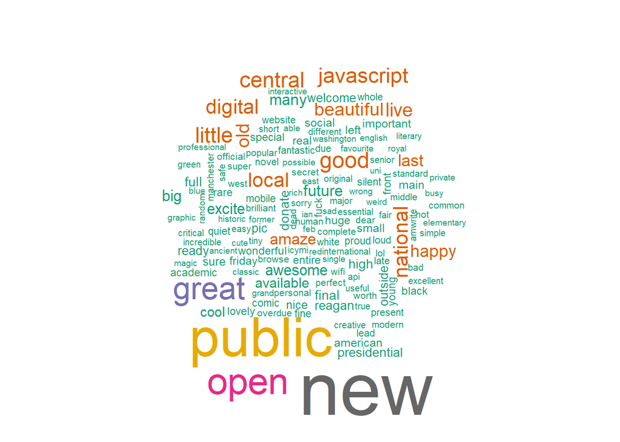

```r
cor.special <- brewer.pal(8,"Dark2")
adj.cloud <- adj.all[1:150,]
wordcloud(adj.cloud$word, adj.cloud$freq, scale=c(5,.5),  # make a word cloud
          colors=cor.special, ordered.colors=F)
```

## Positive vs Negative

We estimated the sentiment of each tweets and score them. A positive sentiment_polarity means the tweet is a positive one. A negative_polarity means the tweet is a negative one. We classified the tweets into positive and negative, and analyzed both positive and negative tweets below.

### Analysis 1: LASSO

Use LASSO to analyze the relationship between each word and sentiment of people.

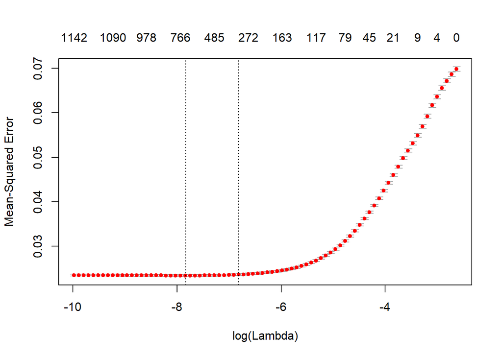

Prediction Error is small (0.024), so the model is acceptable.

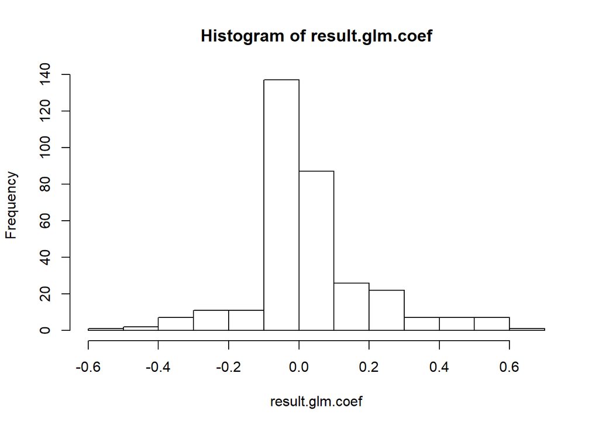

#### Postive word cloud

Extract words with postitive coefficients (words that have positive corelations to sentiments) The following words are 20 words with most positive coef’s.

```
##    awesome   greatest  excellent    perfect       best  wonderful
##     0.6031     0.5988     0.5932     0.5918     0.5833     0.5763
##  beautiful incredible        win  brilliant        lol      happy
##     0.5675     0.5243     0.4896     0.4663     0.4613     0.4587
##      proud      great    welcome    popular       fair       good
##     0.4582     0.4468     0.4220     0.3625     0.3612     0.3563
##       sexy       nice
##     0.3258     0.3243
```

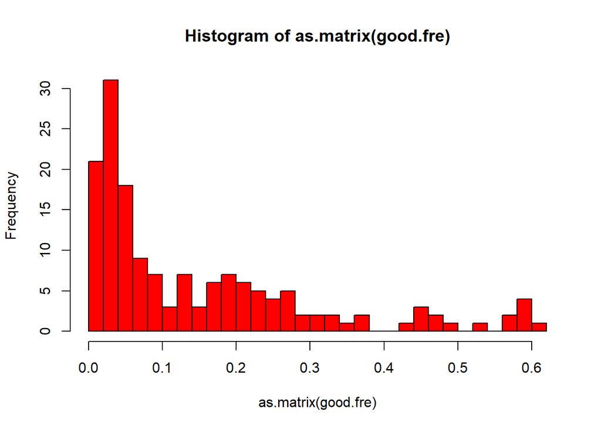

Below is the wordcloud of all the ppositive words from all 2015 tweets. The larger the word is, the more positive it correlates to sentiment. People in 2015 thinks libraries are perfect, excellent, greatest and etc.

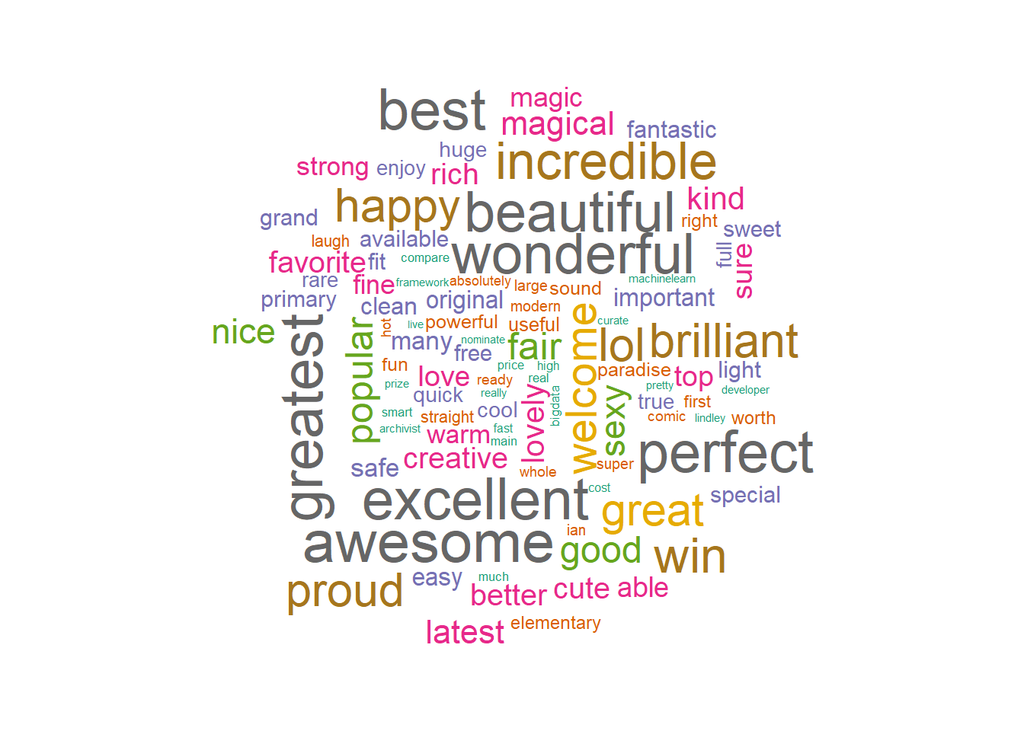

#### Negative word cloud

Similarly to the negative coef’s which is positively correlated to be a tweet with negative sentiment. The following words are 20 words with most negative coef’s.

```
##      base      hate       bad      cold     weird       sad    random
##    0.5493    0.4876    0.4400    0.3597    0.3430    0.3420    0.3357
##     wrong     sorry      fail    behind    secret      fuck    common
##    0.3346    0.3319    0.3161    0.2806    0.2786    0.2583    0.2549
##      poor      game      late      mean seriously      hard
##    0.2527    0.2439    0.2278    0.2095    0.2035    0.2024
```

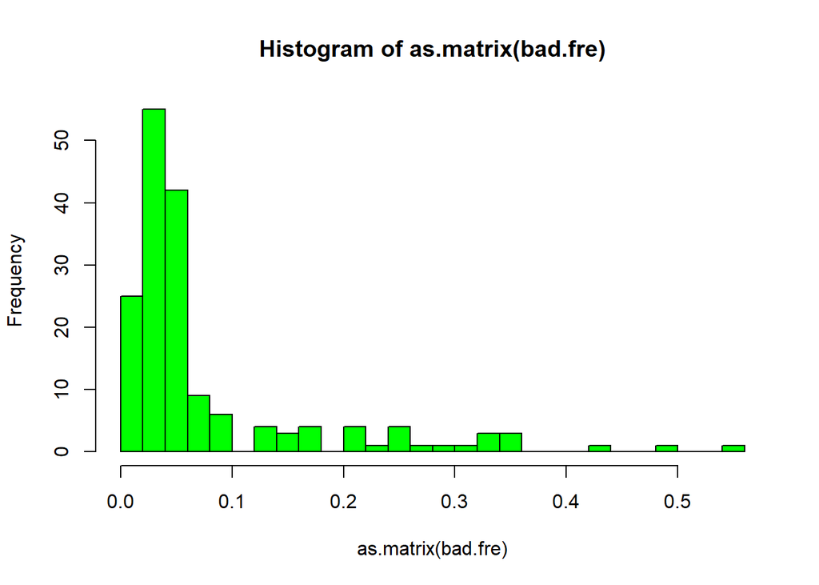

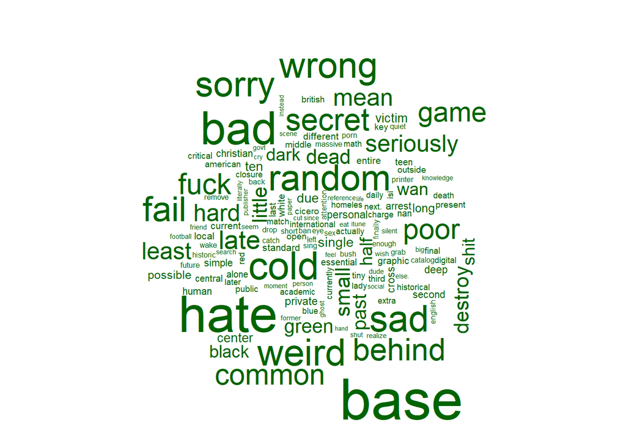

#### Put two clouds together

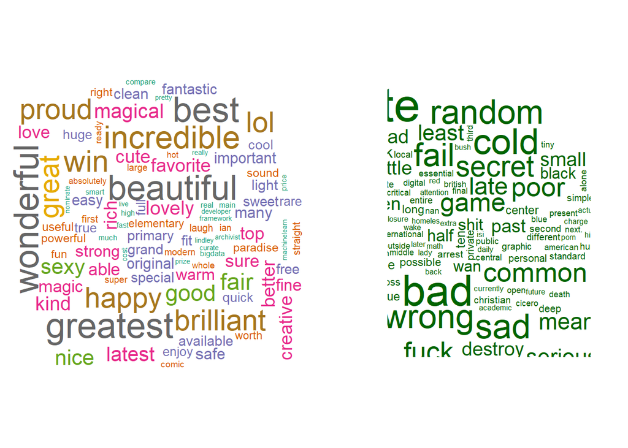

## Sentiment vs Month

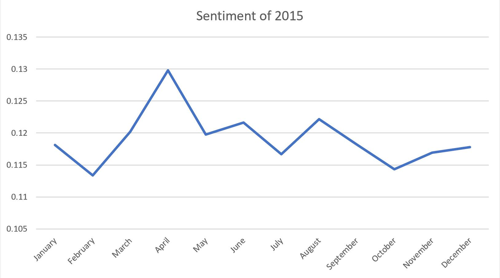

```r
sent <- data %>% group_by(Month) %>% summarize(sent_mean = mean(sentiment_polarity))
sent
```

```
## # A tibble: 12 x 2
##    Month     sent_mean
##    <chr>         <dbl>
##  1 April         0.130
##  2 August        0.122
##  3 December      0.118
##  4 February      0.113
##  5 January       0.118
##  6 July          0.117
##  7 June          0.122
##  8 March         0.120
##  9 May           0.120
## 10 November      0.117
## 11 October       0.114
## 12 September     0.118
```

```r
summary(sent$sent_mean)
```

```
##    Min. 1st Qu.  Median    Mean 3rd Qu.    Max.
##  0.1134  0.1169  0.1182  0.1191  0.1205  0.1298
```

## Pie chart of percentage of sentiment

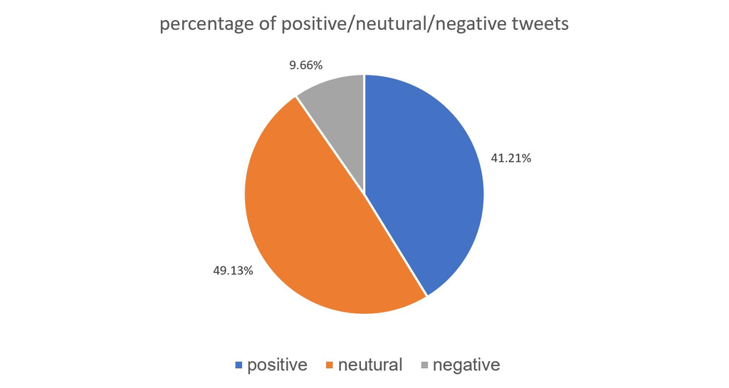